# Lab9 R part

## Part-2: R

Complete the exercises below in an `.rmd` file.

### Q-2.1

Explore the web-application found at the following link

**Q-2.1.a** Use the training dataset where the two classes are easily separable, i.e. with two separated blobs in the upper and lower left quadrant. Train your model. How well does your classifier do? Provide a screenshot of the result.

click here

Use the playground to create an architecture for logistic regression for binary classification. We’ll have two inputs and one output.

**Comment:**

The logistic regression classifier without hidden layer does very well. It can separate the data to correct classes perfectly. The result is shown in the screenshot below.

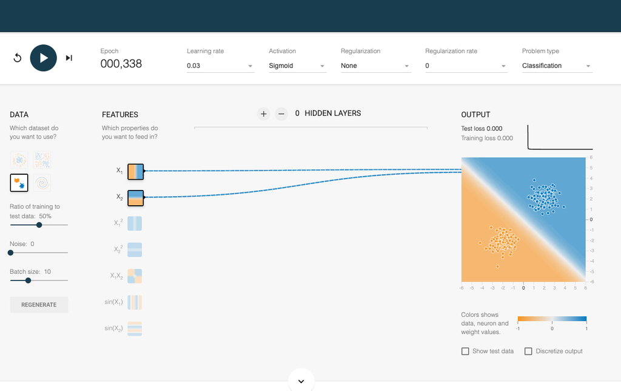

**Q-2.1.b** What are your fitted weights? Use those weights to compute (by hand) what the predicted probability for two arbitrary sample points, verify your intuition.

**Answer:** The fitted logistic regression model is:

$$P(y=1 \mid x) = \frac{1}{1 + e^{-(w_1 x_1 + w_2 x_2 + b)}}$$

Fitted weights: $w_1 = 0.89$ | $w_2 =1.1$ | $b = 0$

**Point A: $(x_1 = 3, x_2 = 3)$**

$$z_A = (0.89)(3) + (1.1)(3) = 5.97$$

$$P_A = \frac{1}{1 + e^{-5.97}} = 0.9975$$

**Point B: $(x_1 = -3, x_2 = -3)$**

$$z_B = (0.89)(-3) + (1.1)(-3) = -5.97$$

This result is consistent with the result from the neural network space output.

**Q-2.1.c** Now use the bullseye data and try to fit this data with logistic regression. Does it work? Provide a screenshot of the result.

**Answer:** With no transformations of the features and change of hypter parameters, fitting bullseye data with logistic regression does not work well as shown in the sreenshot.

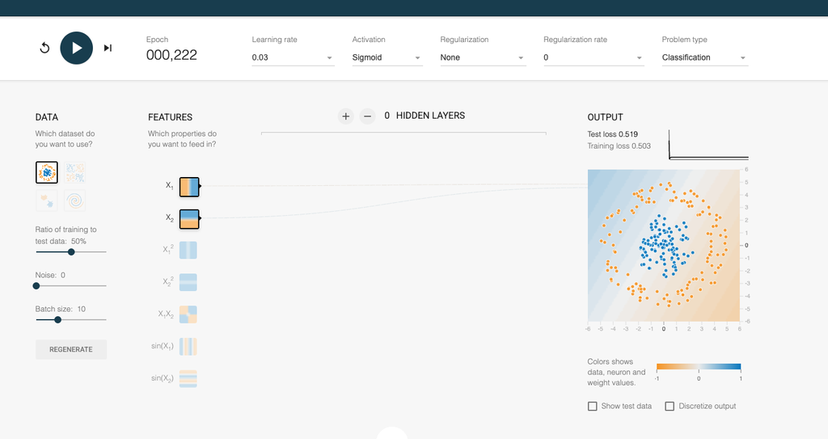

**Q-2.1.c** Try using different transformations of the data. See if you can get logistic regression to fit this data. Can you get it to separate with a single layer?

**Answer:** Yes, by doing quadratic transformations on x1 and x2, logistic regression can already separate data very well with a no hidden layer as shown on the screenshot below.

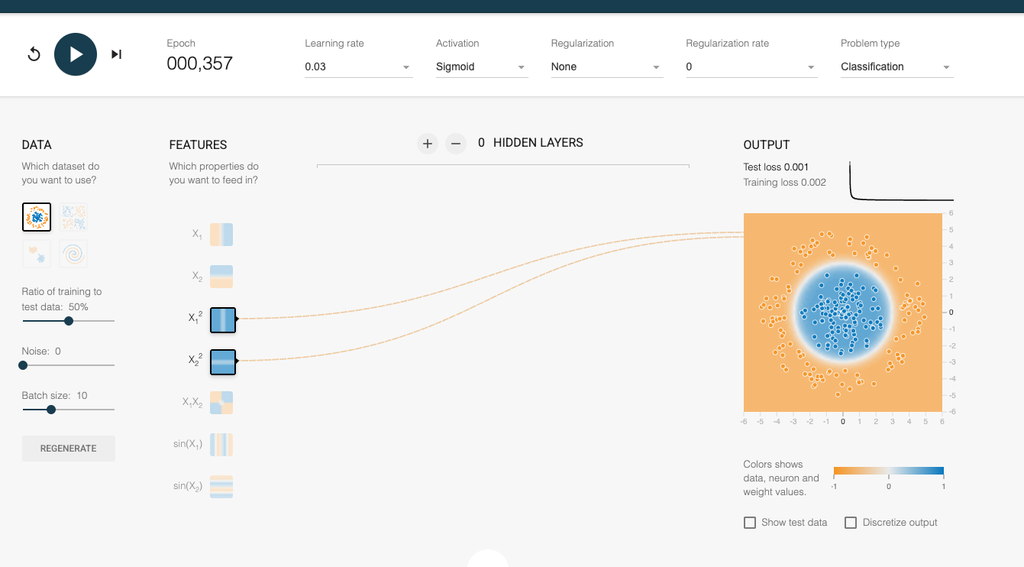

**Q-2.1.d** Explore adding hidden layers with 2 or 3 units and fit the model with different activations. Can you get it to work perfectly? Try adding another unit to the hidden layer. Comment on what is the simplest model that can still fit this dataset. Provide a screenshot of the result

**Answer:** When adding 2 units hidden layers with 3 and 2 neuron for each, and set activation as Relu, the data can be separated very well as shown in the screenshot below.

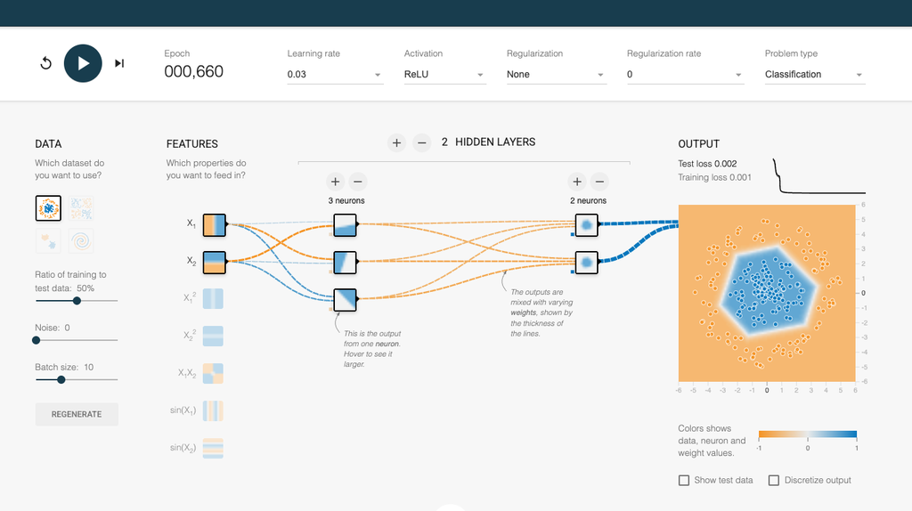

Adding the third hidden layer with 1 neuron doesn’t make necessary/meaningful improvement (shown in below screenshot) as the 2 hidden layer model already perfomrs very well.

The simpliest model that separate the model well is **2 hidden layers** with **3 neurons on first layer and 2 neurons on the second layer**. **Activation is Relu**.

I also tried changing the activation to **Tanh**, which provides a sligtly better result but no meaningful difference from the Relu activation result.

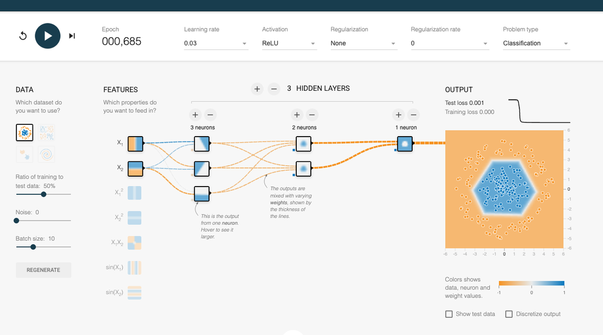

**Q-2.1.e** (i) Try the spiral-data set, which is more difficult. Try any architectures and activation functions that you want. How well can you do? What do you notice? Include a screenshot of your final model architecture.

**Answer:** By adding **3 hidden layers**, **activation = Tahn**, and transformations of x1 and x2 including **x1^2, x2^2, sin(x1), sin(x2), x1x2**, the model can finally separate the spiral data very well with only 0.003 error rate.

Below is the architecture:

- 3 hidden layers: first layer has 8 neurons; second layer has 8 neurons; third layer has 2 neuron
- activation: Tahn
- features: x1, x2, x1^2, x2^2, x1*x2, sin(x1), sin(x2)

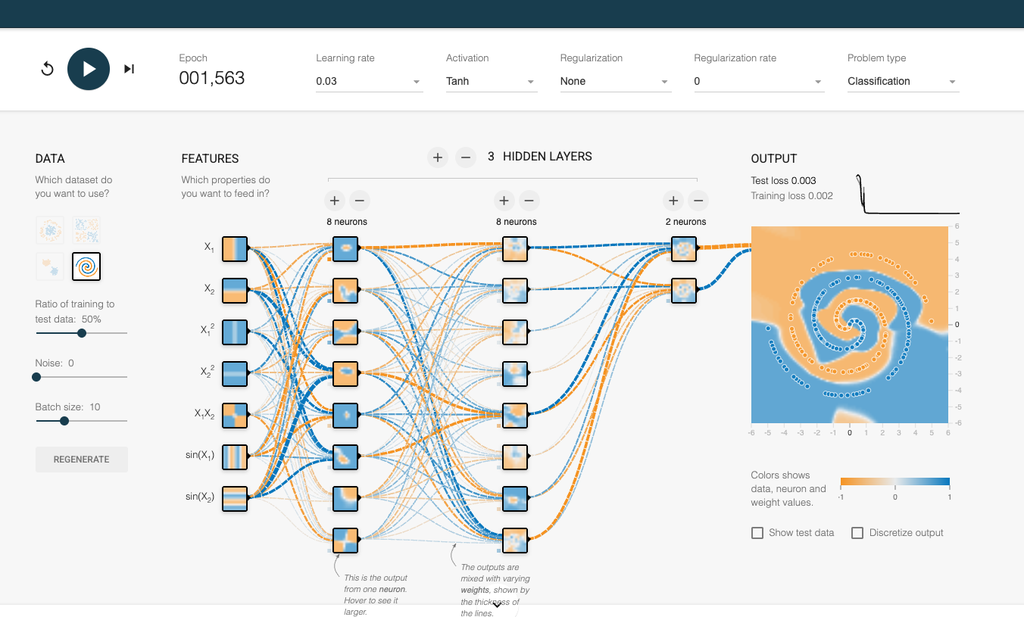

### Q-2.2

Let’s verify that we understand the similarities between Neural Network and other models that we’ve talked about.

Specifically, we’ll establish that Multiple Regression (and Logistic Regression) are special cases of Neural Networks under very simple architectures.

First, we generate some sample data for simple regression.

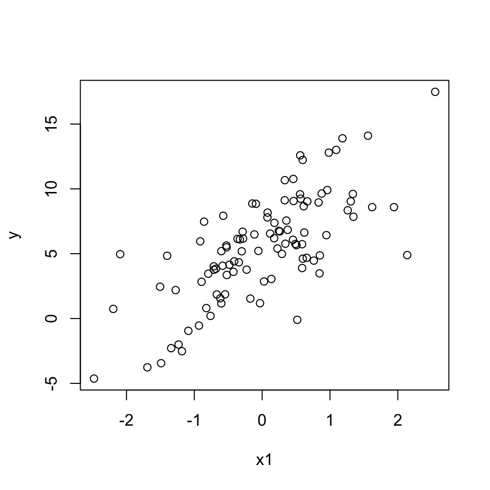

```r
# IMPORT
library(nnet)

x1 <- rnorm(100)
x2 <- rnorm(100)
y <- 5 +  2*x1 + -3*x2 + rnorm(100)
plot(x1,y)
```

```r
df = data.frame(Y=y, X1 = x1, X2 = x2)
```

1. Fit a linear model to this data in order to estimate the regression coefficients $\beta_0$ and $\beta_1$. Do this using built-in R methods we’ve learned previously.

```r
model <- lm(Y ~ X1 + X2, data = df)
summary(model)
```

```
##
## Call:
## lm(formula = Y ~ X1 + X2, data = df)
##
## Residuals:
##      Min       1Q   Median       3Q      Max
## -2.58483 -0.40140 -0.00564  0.59249  1.71530
##
## Coefficients:
##             Estimate Std. Error t value Pr(>|t|)
## (Intercept)  5.00326    0.09645   51.88   <2e-16 ***
## X1           2.21633    0.10776   20.57   <2e-16 ***
## X2          -2.87776    0.10466  -27.50   <2e-16 ***
## ---
## Signif. codes:  0 '***' 0.001 '**' 0.01 '*' 0.05 '.' 0.1 ' ' 1
##
## Residual standard error: 0.9457 on 97 degrees of freedom
## Multiple R-squared:  0.9461, Adjusted R-squared:  0.945
## F-statistic: 852.1 on 2 and 97 DF,  p-value: < 2.2e-16
```

2. Let’s do the same with a neural net, but one with a simple architecture. A neural net with no hidden layer just describes an architecture where each input feature is linearly combined (via some weights) to create an output feature. This will be identical to Multiple Regression if we have no non-linear transformations along the way. Create such a neural net with the nnet package and confirm that you can recover the right parameter weights.

With nnet, to do regression output (as opposed to classification output), use the argument “linout = TRUE”. Also, use the argument “skip = TRUE” to confirm that you intend to *skip* the hidden layer and just go straight from the input to the output layer. Comments on the neural net architecture and weights, do they match your expectation?

```r
library(nnet)

# fit neural network with no hidden layer
nn_model = nnet(
  Y ~ X1 + X2,
  data = df,
  size = 0,
  linout = TRUE,   # regression
  skip = TRUE, # skip hidden layer
  trace = FALSE
)

weights = nn_model$wts
# print weights
cat("Neural Net output parameter weights:\n")
```

```
## Neural Net output parameter weights:
```

```r
print(weights)
```

```
## [1]  5.003263  2.216326 -2.877762
```

**Comment:**

Using `nnet` with `linout = TRUE` and `skip = TRUE` results in a model that performs linear regression with no hidden layer, where the input features are directly connected to the output. This setup is equivalent to multiple linear regression.

The estimated weights from the neural network are 2.2163258 and -2.8777622.

The weights are very close to the expected parameters, with only minor differences attributable to noise in the data and estimation variability, indicating that the model has successfully recovered the correct linear relationship.

Overall, the architecture and learned weights align well with expectations for a linear model without hidden layers.

3. But we can choose any ANN architecture we like, we can have a complex an nonlinear model. Choose a model with a non-zero hidden layer and fit. Comment on the resulting error and model.

```r
# fit neural network with hidden layer
nn_model_1_hidden_layer = nnet(
  Y ~ X1 + X2,
  data = df,
  size = 3,  # one hidden layer with 2 neurons
  linout = TRUE,   # regression
  trace = FALSE
)

# predictions
pred_nn_1_hidden_layer = predict(nn_model_1_hidden_layer, df)

# mse
mse = mean((df$Y - pred_nn_1_hidden_layer)^2)
mse
```

```
## [1] 0.7702875
```

**Comment:** The mean squared error (MSE) of the neural network with a hidden layer is approximately 0.7702875, indicating the model fits the data pretty well with some residual error.

Since the true relationship between y and x1 and x2 is linear ($Y = 5 + 2X1 - 3X2 + \epsilon$), the neural network with a hidden layer does not significantly improve model performance compared to the linear model. The added hidden layer increases model flexibility and complexity, but this is unnecessary for a linear relationship and might cause overfitting.

A simple linear model or neural network with no hidden layer are enought to fit the data.

### Q-2.3

Neural Networks are “universal function approximators”, which means if you have a big enough neural network, then it will be flexible enough to fit any function you wish.

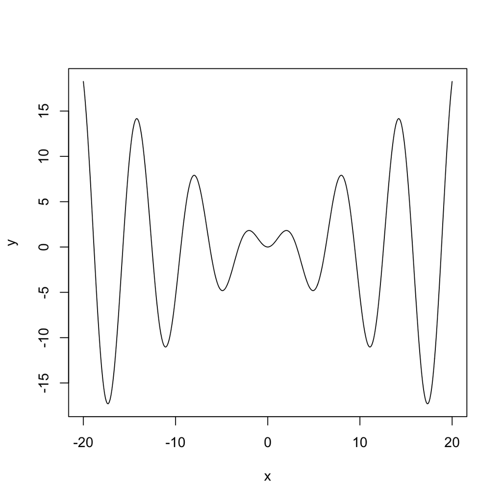

```r
sinc = function(x){x*sin(x)} # Define the function

xx <- seq(-20,20,by=.1) # vector of x variables for plotting
mydf = data.frame(x=xx, y = sinc(xx))

plot(y ~x, data = mydf, type = 'l')
```

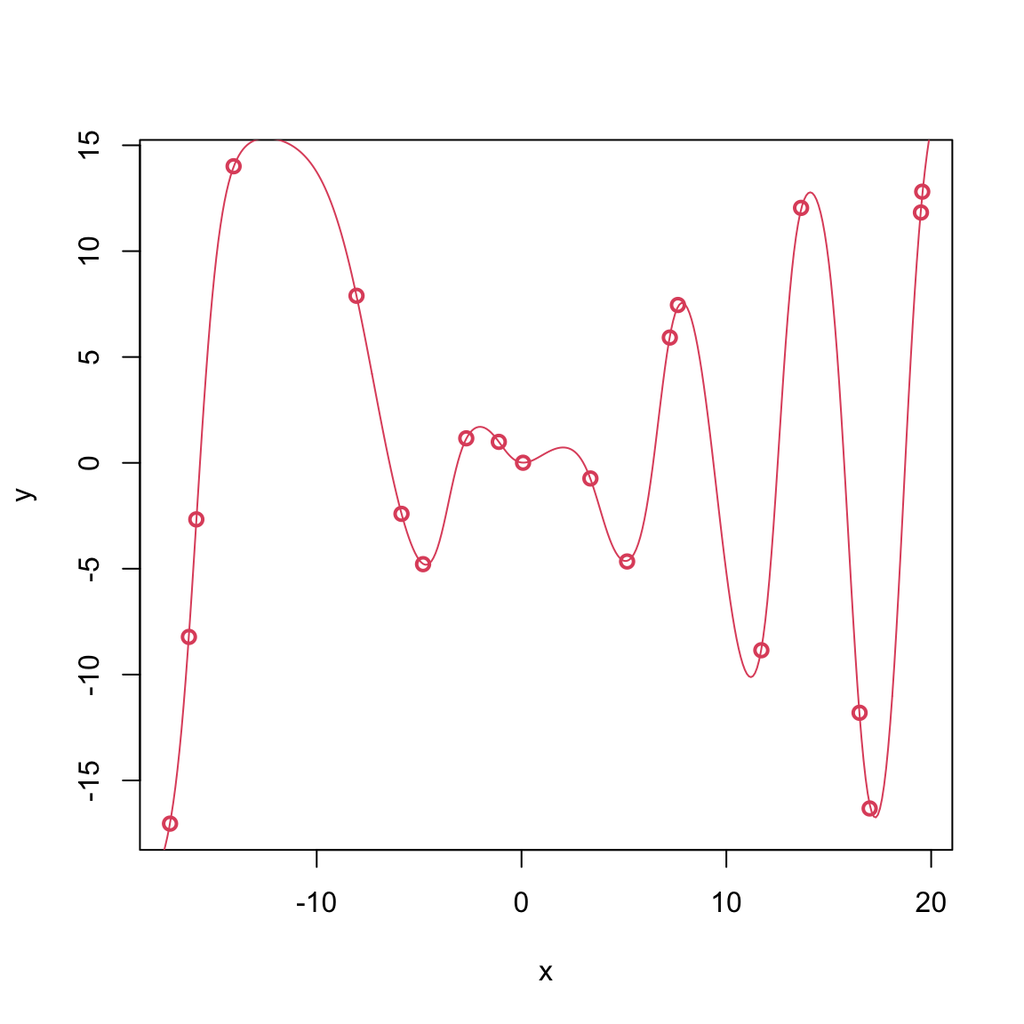

```r
# Now we will create a dataset by drawing a few samples from the domain of this function and evaluating this function at those locations.
x <- runif(20, min = -20, max = 20 )
mydf.train = data.frame(x = x, y = sinc(x))

plot(y ~x, data = mydf.train, lwd = 2, col = 2)

# Train network and make predictions
# Note linout = T
net1 <- nnet(y ~x, data = mydf.train, size = 20, decay = .001, maxit = 2000, linout = T)
pred <- predict(net1, newdata = mydf, type = "r")

# Make a plots of predictions, overlaid on the datapoints and the true function
lines(xx,pred, col = 2)
```

Repeat the above by changing the hyper-parameters of the model such as the size of the hidden layer. Plot the results. Be sure to include an example of a small model (such as size=2) and a large model (such as size=40). Comment on what you saw and how it relates to the bias-variance tradeoff. Thinking back to the phrase “universal function approximator”, what would it take for a neural network to truly fit any complex function we wish?

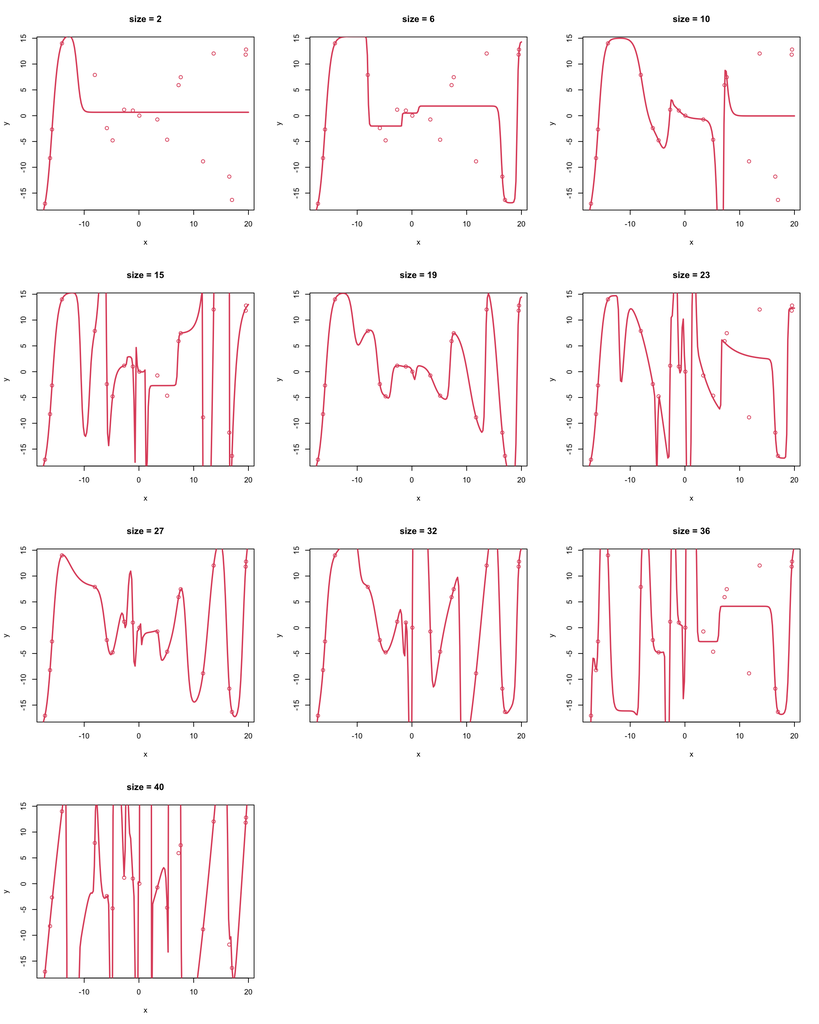

```r
library(nnet)

# Create grid for plotting
xx <- seq(-20, 20, length = 200)

# Set layout: 2 rows × 5 columns (10 plots)
par(mfrow = c(4, 3))

# Loop over 10 different hidden layer sizes
sizes <- seq(2, 40, length.out = 10)

for (s in sizes) {

  # Fit model
  net <- nnet(
    y ~ x,
    data = mydf.train,
    size = round(s),
    linout = TRUE,
    trace = FALSE,
    maxit = 2000
  )

  # Predict on dense grid
  pred <- predict(net, newdata = data.frame(x = xx))

  # Plot training data
  plot(y ~ x, data = mydf.train,
       main = paste("size =", round(s)),
       col = 2)

  # Overlay prediction
  lines(xx, pred, col = 2, lwd = 2)
}
```

**Comment:**

While larger networks are more flexible, they become more computationally costly, harder to interpret, and do not necessarily improve performance on unseen data.